# Lecture 06 H testing and simple tests II

Author

Bill Perry

# Brief review

- H test for a single population
- 1- and 2-sided tests
- H test for two populations
- Assumptions of parametric tests

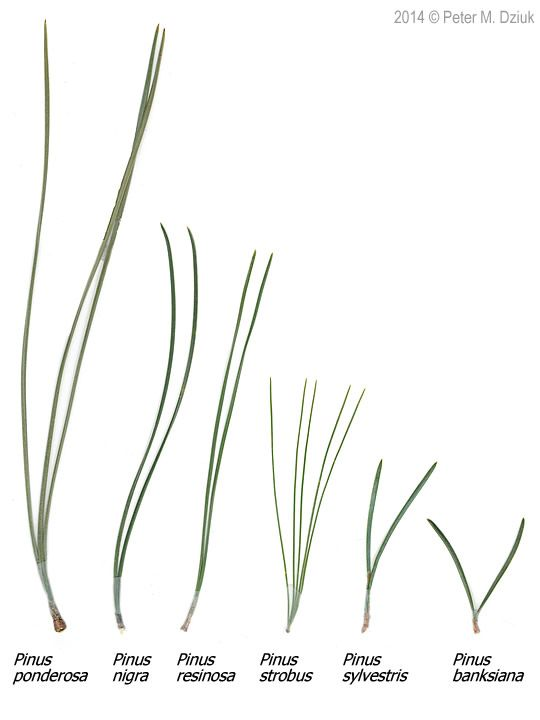

# Lecture 5 overview

- Assumptions of parametric tests
- Statistical vs. biological significance
- Robust tests
- Rank-based tests
- Permutation tests
- Assignment 1

Lake Trout

[figure not shown]

[source](https://news.orvis.com/fly-fishing/fish-facts-lake-trout-salvelinus-namaycush)

# Assumptions of parametric tests

- T-tests are **parametric** tests
- Parametric tests: specify/assume probability distribution from which parameters came
- Non-parametric tests: no assumption about probability distribution
- Mukasa et al 2021 DOI: 10.4236/ojbm.2021.93081

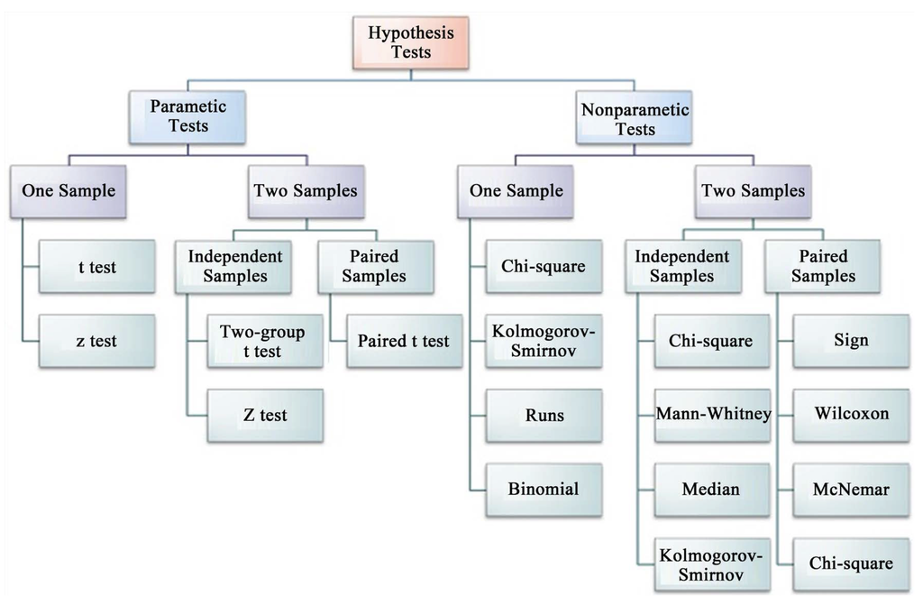

# Assumptions of parametric tests

- If assumptions of parametric test violated, test becomes unreliable
- This is because test statistic may no longer follow distribution
- Most parametric tests robust to mild/moderate violations of below assumptions

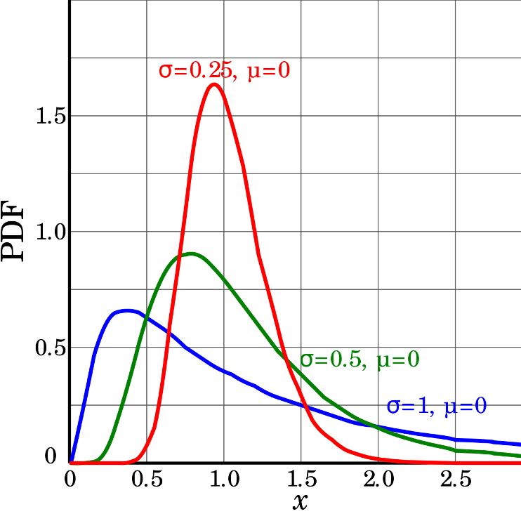

# Assumptions of parametric tests

- Basic assumptions of parametric t-tests:
- Normality, equal variance, random sampling, no outliers
- Normality: Samples from normally distributed population
  - Graphical tests: histograms, dotplots, boxplots, qq-plots
  - “Formal” tests: Shapiro-Wilk test

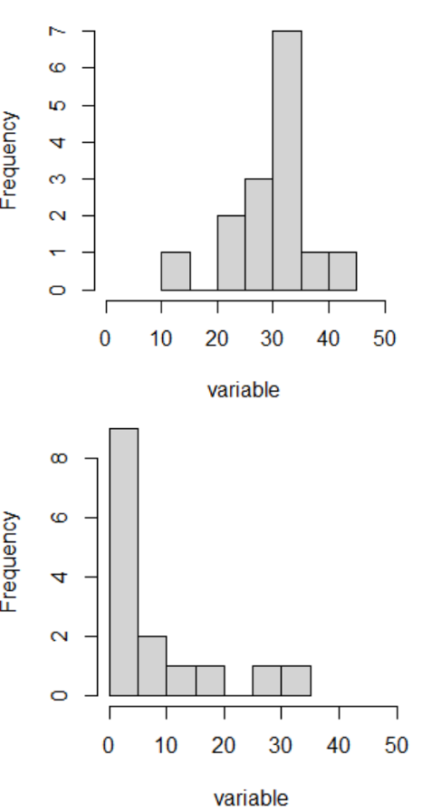

# Assumptions of parametric tests

- Equal variance: samples are from populations with similar degree of variability
- Graphical tests: boxplots
- “Formal” tests: F-ratio test
- Parametric tests most robust to violations of normality and equal var. assumptions when samples sizes equal

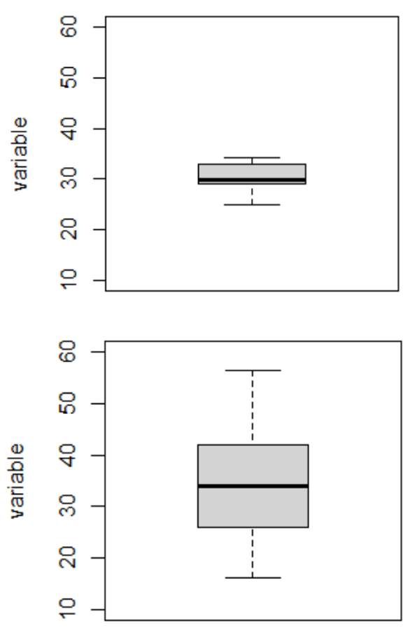

# Assumptions of parametric tests

- Normality, equal variance, random sampling, no outliers
- Random sampling: samples are randomly collected from populations; part of experimental design
- Necessary for sample -> population inference

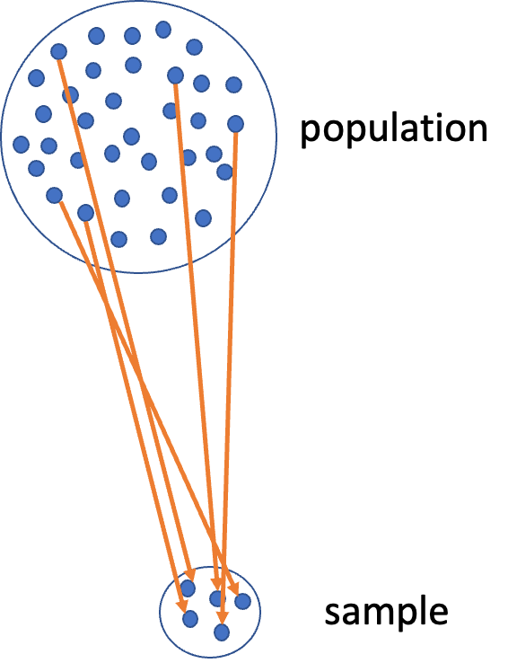

# Assumptions of parametric tests

- Normality, equal variance, random sampling, no outliers
- No outliers: no “extreme” values that are very different from rest of sample
- Graphical tests: boxplots, histograms
- “Formal tests”: Grubb’s test
- Note: outliers also problem for non-parametric tests

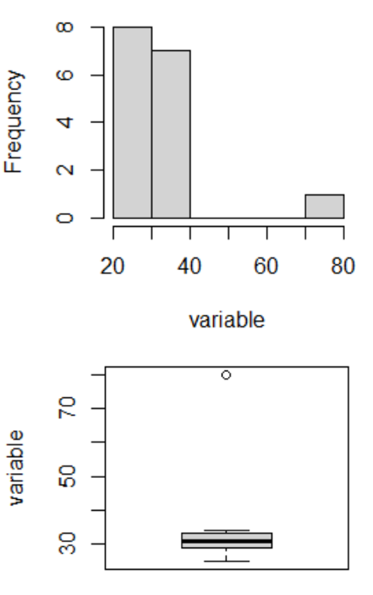

# Homework take-up

- Perform 2-sample t-test:
  - pop A: 5.3, 5.6, 4.3, 4.9, 5.3, 4.1, 5.2, 5.0 cm
  - pop B: 6.1, 4.7, 5.9, 4.7, 6.2, 6.0, 5.4, 4.9 cm
- ȳ<sub>popA</sub> - ȳ<sub>popB</sub> = -0.53
- s<sub>ȳopA-ȳopB</sub> = 0.29
- t = -1.80
- df = 14
- p (estimated from t-table) = 0.05 < p < 0.1
- Writeup: “a 2-tailed, independent 2-sampe t-test showed no significant difference bw beak length of pop A (4.96 cm ± 0.52 SD) and pop B (5.49 ± 0.64) at á=0.05: t(14) =-1.80, p = 0.094”

# Homework take-up

- Look through the ecological literature and find an example of a published manuscript that uses either a t-test of one of the tests mentioned in Q2. Provide the following information:
  - Reference for paper
  - Scientific question being addressed
  - Specific hypothesis tested (in mathematical notation)
  - The results of the t test (t, df, p) and the author’s conclusions

# Statistical vs. biological significance

- Statistical significance: difference unlikely due to chance
- Says nothing about biological significance of difference!
- With large sample size can detect very small differences between populations
- E.g.: consider 2 snail populations, A and B: Ho: µ~size A~ = µ~size B~; Ha: µ~size A~ ≠ µ~size B~

# Statistical vs. biological significance

# Statistical vs. biological significance

- Finally, statistically significant difference…
- Meaningful? Ecologically significant? Statistics can’t answer this question
- **IMPORTANT** to report info that can assess biological significance
- “A two-tailed, two-sample independent t-test showed significant difference in size between pop. A (4.99 mm ± 1.99 SD) and pop. B (5.06 mm ± 1.99 SD) at á=0.05 (t = -4.47, df = 59998, p-value < 0.0001).”

# Assumptions of parametric tests

- Basic assumptions of parametric t-tests:
- Normality, equal variance, random sampling, no outliers
- What to do if assumptions are violated?

# Homework take-up

- t-tests have several assumptions. Alternative tests, with more relaxed assumptions, are available to statisticians. In which case would you use the following tests?
  - Welch’s t-test: *when distribution normal but variance unequal*
  - Permutation test for two samples: *when distribution not normal (but both groups should still have similar distributions and ~equal variance)*
  - Mann-Whitney-Wilcoxon test: *when distribution not normal and/or outliers are present (but both groups should still have similar distributions and ~equal variance)*

# Assumptions of parametric tests

- QQ-plots: tool for assessing normality
- On x- theoretical quantiles from SND
- On y- ordered sample values
- Deviation from normal can be detected as deviation from straight line

# Assumptions of parametric tests

- In some cases, data can be mathematically “transformed” to meet assumptions of parametric tests

# Robust tests

- Welch’s t-test: common “robust” test for means of two populations
- Robust to violation of equal variance assumption, deals better with unequal sample size
- Parametric test (assumes normal distribution)
- Calculates a t statistic but recalculates df based on samples sizes and s

# Robust tests

- In R: t.test(y1, y2, var.equal = FALSE, paired = FALSE) will use the Welch approach

# Rank based tests

- Rank-based tests: no assumptions about distribution (non-parametric)
- Ranks of data: observations assigned ranks, sums (and signs for paired tests) of ranks for groups comparted
- Mann-Whitney U test common alternative to independent samples t-test
- Wilcoxon signed-rank test is alternative to paired t-test

# Rank based tests

- Assumptions: similar distributions for groups, equal variance
- Less power than parametric tests
- Best when normality assumption can not be met by transformation (weird distribution) or large outliers

# Permutation tests

- Permutation tests based on resampling: reshuffling of original data
- Resampling allows parameter estimation when distribution unknown, including SEs and CIs of statistics (means, medians)
- Common approach is bootstrap: resample sample with replacement many times, recalculate sample stats

# Permutation tests

- Sample A: n = 40, ȳ= 1.72, s = 4.17
- Sample B: n = 35, ȳ= 4.50, s = 4.83
- Ho: µ<sub>A</sub> = µ<sub>B</sub>, Ha: µ<sub>A</sub> ≠µ<sub>B</sub>
- Calculate ∆ in means bw two groups (2.78)

# Permutation tests

# Permutation tests

- In R (using ‘perm’ package):
- permTS(y1, y2, alternative = “two.sided”, method = “exact.mc”, control = permControl(nmc = 10000))
- Assumptions: both groups have similar distribution; equal variance

# R practice

- Get practice doing basic t-tests
- Alternatives in next lecture
- Dataset (squirrel_data.csv) and lab instructions on Canvas
- Answer questions in **bold**
- Due end of Thursday

Back to top